# Heart AI with XGBoost

[Bruce Hartman](https://drbrucehartman.net/brucewebsite/)

Last updated: 29 November, 2023

# Introduction

In this notebook we use XGBoost to make predictions of RestBP from the Heart data. The theory of the model can be found in References [1,2,3].

# Packages

Loading libraries:

```r
library(tidyverse) # used to manipulate data and plot
library(ISLR2) #package contains the data files, but not this one
library(ggfortify) # some extra ggplot functions
library(GGally) # pairs ggplot and other options
library(flextable) # nice displays of printed data
library(DT) #more nice table displays from RStudio
library(broom) # neat model summary
library(car) # useful tools for regression analysis
library(MASS) # for LDA analysis
library(class) # for knn analysis
library(caret) # for confusion matrix and for crossvalidation

library(xgboost)
```

# Data

```r
readRDS(file="Heartall.rds")
```

| Age | Sex | ChestPain | RestBP | Chol | Fbs | RestECG | MaxHR | ExAng | Oldpeak | Slope | Ca | Thal | AHD |
| --- | --- | --- | --- | --- | --- | --- | --- | --- | --- | --- | --- | --- | --- |
| 63 | 2 | 4 | 145 | 233 | 2 | 3 | 150 | 1 | 2.3 | 3 | 1 | 1 | 1 |
| 67 | 2 | 1 | 160 | 286 | 1 | 3 | 108 | 2 | 1.5 | 2 | 4 | 2 | 2 |
| 67 | 2 | 1 | 120 | 229 | 1 | 3 | 129 | 2 | 2.6 | 2 | 3 | 3 | 2 |
| 37 | 2 | 2 | 130 | 250 | 1 | 1 | 187 | 1 | 3.5 | 3 | 1 | 2 | 1 |
| 41 | 1 | 3 | 130 | 204 | 1 | 3 | 172 | 1 | 1.4 | 1 | 1 | 2 | 1 |
| 56 | 2 | 3 | 120 | 236 | 1 | 1 | 178 | 1 | 0.8 | 1 | 1 | 2 | 1 |
| 62 | 1 | 1 | 140 | 268 | 1 | 3 | 160 | 1 | 3.6 | 3 | 3 | 2 | 2 |
| 57 | 1 | 1 | 120 | 354 | 1 | 1 | 163 | 2 | 0.6 | 1 | 1 | 2 | 1 |
| 63 | 2 | 1 | 130 | 254 | 1 | 3 | 147 | 1 | 1.4 | 2 | 2 | 3 | 2 |
| 53 | 2 | 1 | 140 | 203 | 2 | 3 | 155 | 2 | 3.1 | 3 | 1 | 3 | 2 |

[output cut: 287 more lines]

```r
Heartall
```

| Age | Sex | ChestPain | RestBP | Chol | Fbs | RestECG | MaxHR | ExAng | Oldpeak | Slope | Ca | Thal | AHD |
| --- | --- | --- | --- | --- | --- | --- | --- | --- | --- | --- | --- | --- | --- |
| 63 | 2 | 4 | 145 | 233 | 2 | 3 | 150 | 1 | 2.3 | 3 | 1 | 1 | 1 |
| 67 | 2 | 1 | 160 | 286 | 1 | 3 | 108 | 2 | 1.5 | 2 | 4 | 2 | 2 |
| 67 | 2 | 1 | 120 | 229 | 1 | 3 | 129 | 2 | 2.6 | 2 | 3 | 3 | 2 |
| 37 | 2 | 2 | 130 | 250 | 1 | 1 | 187 | 1 | 3.5 | 3 | 1 | 2 | 1 |
| 41 | 1 | 3 | 130 | 204 | 1 | 3 | 172 | 1 | 1.4 | 1 | 1 | 2 | 1 |
| 56 | 2 | 3 | 120 | 236 | 1 | 1 | 178 | 1 | 0.8 | 1 | 1 | 2 | 1 |
| 62 | 1 | 1 | 140 | 268 | 1 | 3 | 160 | 1 | 3.6 | 3 | 3 | 2 | 2 |
| 57 | 1 | 1 | 120 | 354 | 1 | 1 | 163 | 2 | 0.6 | 1 | 1 | 2 | 1 |
| 63 | 2 | 1 | 130 | 254 | 1 | 3 | 147 | 1 | 1.4 | 2 | 2 | 3 | 2 |
| 53 | 2 | 1 | 140 | 203 | 2 | 3 | 155 | 2 | 3.1 | 3 | 1 | 3 | 2 |

[output cut: 287 more lines]

# Data Description

```r
Heartall %>% summary
```

```
      Age             Sex          ChestPain         RestBP           Chol            Fbs
 Min.   :29.00   Min.   :1.000   Min.   :1.000   Min.   : 94.0   Min.   :126.0   Min.   :1.000
 1st Qu.:48.00   1st Qu.:1.000   1st Qu.:1.000   1st Qu.:120.0   1st Qu.:211.0   1st Qu.:1.000
 Median :56.00   Median :2.000   Median :2.000   Median :130.0   Median :243.0   Median :1.000
 Mean   :54.54   Mean   :1.677   Mean   :1.842   Mean   :131.7   Mean   :247.4   Mean   :1.145
 3rd Qu.:61.00   3rd Qu.:2.000   3rd Qu.:2.000   3rd Qu.:140.0   3rd Qu.:276.0   3rd Qu.:1.000
 Max.   :77.00   Max.   :2.000   Max.   :4.000   Max.   :200.0   Max.   :564.0   Max.   :2.000
    RestECG          MaxHR           ExAng          Oldpeak          Slope             Ca
 Min.   :1.000   Min.   : 71.0   Min.   :1.000   Min.   :0.000   Min.   :1.000   Min.   :1.000
 1st Qu.:1.000   1st Qu.:133.0   1st Qu.:1.000   1st Qu.:0.000   1st Qu.:1.000   1st Qu.:1.000
 Median :2.000   Median :153.0   Median :1.000   Median :0.800   Median :2.000   Median :1.000
 Mean   :1.997   Mean   :149.6   Mean   :1.327   Mean   :1.056   Mean   :1.603   Mean   :1.677
 3rd Qu.:3.000   3rd Qu.:166.0   3rd Qu.:2.000   3rd Qu.:1.600   3rd Qu.:2.000   3rd Qu.:2.000
 Max.   :3.000   Max.   :202.0   Max.   :2.000   Max.   :6.200   Max.   :3.000   Max.   :4.000
      Thal            AHD
 Min.   :1.000   Min.   :1.000
 1st Qu.:2.000   1st Qu.:1.000
 Median :2.000   Median :1.000
 Mean   :2.327   Mean   :1.461
 3rd Qu.:3.000   3rd Qu.:2.000
 Max.   :3.000   Max.   :2.000
```

# Data Wrangling

It’s desirable to scale the data for xgboost.

```r
Heartall.scaled = Heartall %>% sapply(FUN = function (x) {
  (x-min(x))/(max(x)-min(x))})  %>% data.frame
Heartall.scaled %>% summary
```

```
      Age              Sex           ChestPain          RestBP            Chol             Fbs
 Min.   :0.0000   Min.   :0.0000   Min.   :0.0000   Min.   :0.0000   Min.   :0.0000   Min.   :0.0000
 1st Qu.:0.3958   1st Qu.:0.0000   1st Qu.:0.0000   1st Qu.:0.2453   1st Qu.:0.1941   1st Qu.:0.0000
 Median :0.5625   Median :1.0000   Median :0.3333   Median :0.3396   Median :0.2671   Median :0.0000
 Mean   :0.5321   Mean   :0.6768   Mean   :0.2806   Mean   :0.3556   Mean   :0.2771   Mean   :0.1448
 3rd Qu.:0.6667   3rd Qu.:1.0000   3rd Qu.:0.3333   3rd Qu.:0.4340   3rd Qu.:0.3425   3rd Qu.:0.0000
 Max.   :1.0000   Max.   :1.0000   Max.   :1.0000   Max.   :1.0000   Max.   :1.0000   Max.   :1.0000
    RestECG           MaxHR            ExAng           Oldpeak           Slope              Ca
 Min.   :0.0000   Min.   :0.0000   Min.   :0.0000   Min.   :0.0000   Min.   :0.0000   Min.   :0.0000
 1st Qu.:0.0000   1st Qu.:0.4733   1st Qu.:0.0000   1st Qu.:0.0000   1st Qu.:0.0000   1st Qu.:0.0000
 Median :0.5000   Median :0.6260   Median :0.0000   Median :0.1290   Median :0.5000   Median :0.0000
 Mean   :0.4983   Mean   :0.6000   Mean   :0.3266   Mean   :0.1703   Mean   :0.3013   Mean   :0.2256
 3rd Qu.:1.0000   3rd Qu.:0.7252   3rd Qu.:1.0000   3rd Qu.:0.2581   3rd Qu.:0.5000   3rd Qu.:0.3333
 Max.   :1.0000   Max.   :1.0000   Max.   :1.0000   Max.   :1.0000   Max.   :1.0000   Max.   :1.0000
      Thal             AHD
 Min.   :0.0000   Min.   :0.0000
 1st Qu.:0.5000   1st Qu.:0.0000
 Median :0.5000   Median :0.0000
 Mean   :0.6633   Mean   :0.4613
 3rd Qu.:1.0000   3rd Qu.:1.0000
 Max.   :1.0000   Max.   :1.0000
```

#One-Hot encoding of categorical variables

Package `mltools` is best at one-hot encoding. It uses package `data.table`, which is already incorporated into tidyverse.

```r
dfx = one_hot(as.data.table(Heart))
dfx %>% glimpse
```

```
Rows: 297
Columns: 31
$ Obs                    <dbl> 1, 2, 3, 4, 5, 6, 7, 8, 9, 10, 11, 12, 13, 14, 15, 16, 17, 18, 19, 20, …
$ Age                    <dbl> 63, 67, 67, 37, 41, 56, 62, 57, 63, 53, 57, 56, 56, 44, 52, 57, 48, 54,…
$ Sex_0                  <int> 0, 0, 0, 0, 1, 0, 1, 1, 0, 0, 0, 1, 0, 0, 0, 0, 0, 0, 1, 0, 0, 1, 0, 0,…
$ Sex_1                  <int> 1, 1, 1, 1, 0, 1, 0, 0, 1, 1, 1, 0, 1, 1, 1, 1, 1, 1, 0, 1, 1, 0, 1, 1,…
$ ChestPain_asymptomatic <int> 0, 1, 1, 0, 0, 0, 1, 1, 1, 1, 1, 0, 0, 0, 0, 0, 0, 1, 0, 0, 0, 0, 0, 0,…
$ ChestPain_nonanginal   <int> 0, 0, 0, 1, 0, 0, 0, 0, 0, 0, 0, 0, 1, 0, 1, 1, 0, 0, 1, 0, 0, 0, 0, 1,…
$ ChestPain_nontypical   <int> 0, 0, 0, 0, 1, 1, 0, 0, 0, 0, 0, 1, 0, 1, 0, 0, 1, 0, 0, 1, 0, 0, 1, 0,…
$ ChestPain_typical      <int> 1, 0, 0, 0, 0, 0, 0, 0, 0, 0, 0, 0, 0, 0, 0, 0, 0, 0, 0, 0, 1, 1, 0, 0,…
$ RestBP                 <dbl> 145, 160, 120, 130, 130, 120, 140, 120, 130, 140, 140, 140, 130, 120, 1…
$ Chol                   <dbl> 233, 286, 229, 250, 204, 236, 268, 354, 254, 203, 192, 294, 256, 263, 1…
$ Fbs_0                  <int> 0, 1, 1, 1, 1, 1, 1, 1, 1, 0, 1, 1, 0, 1, 0, 1, 1, 1, 1, 1, 1, 0, 1, 1,…
$ Fbs_1                  <int> 1, 0, 0, 0, 0, 0, 0, 0, 0, 1, 0, 0, 1, 0, 1, 0, 0, 0, 0, 0, 0, 1, 0, 0,…
$ RestECG_0              <int> 0, 0, 0, 1, 0, 1, 0, 1, 0, 0, 1, 0, 0, 1, 1, 1, 1, 1, 1, 1, 0, 0, 0, 0,…
```

[output cut: 18 more lines]

```r
dfx.scaled =dfx %>% sapply(FUN = function (x) {
  (x-min(x))/(max(x)-min(x))})  %>% data.frame
dfx.scaled %>% summary
```

```
      Obs              Age             Sex_0            Sex_1        ChestPain_asymptomatic
 Min.   :0.0000   Min.   :0.0000   Min.   :0.0000   Min.   :0.0000   Min.   :0.0000
 1st Qu.:0.2458   1st Qu.:0.3958   1st Qu.:0.0000   1st Qu.:0.0000   1st Qu.:0.0000
 Median :0.4950   Median :0.5625   Median :0.0000   Median :1.0000   Median :0.0000
 Mean   :0.4973   Mean   :0.5321   Mean   :0.3232   Mean   :0.6768   Mean   :0.4781
 3rd Qu.:0.7475   3rd Qu.:0.6667   3rd Qu.:1.0000   3rd Qu.:1.0000   3rd Qu.:1.0000
 Max.   :1.0000   Max.   :1.0000   Max.   :1.0000   Max.   :1.0000   Max.   :1.0000
 ChestPain_nonanginal ChestPain_nontypical ChestPain_typical     RestBP            Chol
 Min.   :0.0000       Min.   :0.000        Min.   :0.00000   Min.   :0.0000   Min.   :0.0000
 1st Qu.:0.0000       1st Qu.:0.000        1st Qu.:0.00000   1st Qu.:0.2453   1st Qu.:0.1941
 Median :0.0000       Median :0.000        Median :0.00000   Median :0.3396   Median :0.2671
 Mean   :0.2795       Mean   :0.165        Mean   :0.07744   Mean   :0.3556   Mean   :0.2771
 3rd Qu.:1.0000       3rd Qu.:0.000        3rd Qu.:0.00000   3rd Qu.:0.4340   3rd Qu.:0.3425
 Max.   :1.0000       Max.   :1.000        Max.   :1.00000   Max.   :1.0000   Max.   :1.0000
     Fbs_0            Fbs_1          RestECG_0        RestECG_1         RestECG_2          MaxHR
 Min.   :0.0000   Min.   :0.0000   Min.   :0.0000   Min.   :0.00000   Min.   :0.0000   Min.   :0.0000
 1st Qu.:1.0000   1st Qu.:0.0000   1st Qu.:0.0000   1st Qu.:0.00000   1st Qu.:0.0000   1st Qu.:0.4733
 Median :1.0000   Median :0.0000   Median :0.0000   Median :0.00000   Median :0.0000   Median :0.6260
 Mean   :0.8552   Mean   :0.1448   Mean   :0.4949   Mean   :0.01347   Mean   :0.4916   Mean   :0.6000
 3rd Qu.:1.0000   3rd Qu.:0.0000   3rd Qu.:1.0000   3rd Qu.:0.00000   3rd Qu.:1.0000   3rd Qu.:0.7252
 Max.   :1.0000   Max.   :1.0000   Max.   :1.0000   Max.   :1.00000   Max.   :1.0000   Max.   :1.0000
    ExAng_0          ExAng_1          Oldpeak          Slope_1         Slope_2          Slope_3
 Min.   :0.0000   Min.   :0.0000   Min.   :0.0000   Min.   :0.000   Min.   :0.0000   Min.   :0.00000
 1st Qu.:0.0000   1st Qu.:0.0000   1st Qu.:0.0000   1st Qu.:0.000   1st Qu.:0.0000   1st Qu.:0.00000
 Median :1.0000   Median :0.0000   Median :0.1290   Median :0.000   Median :0.0000   Median :0.00000
 Mean   :0.6734   Mean   :0.3266   Mean   :0.1703   Mean   :0.468   Mean   :0.4613   Mean   :0.07071
 3rd Qu.:1.0000   3rd Qu.:1.0000   3rd Qu.:0.2581   3rd Qu.:1.000   3rd Qu.:1.0000   3rd Qu.:0.00000
 Max.   :1.0000   Max.   :1.0000   Max.   :1.0000   Max.   :1.000   Max.   :1.0000   Max.   :1.00000
      Ca_0             Ca_1             Ca_2             Ca_3           Thal_fixed
 Min.   :0.0000   Min.   :0.0000   Min.   :0.0000   Min.   :0.00000   Min.   :0.00000
 1st Qu.:0.0000   1st Qu.:0.0000   1st Qu.:0.0000   1st Qu.:0.00000   1st Qu.:0.00000
 Median :1.0000   Median :0.0000   Median :0.0000   Median :0.00000   Median :0.00000
 Mean   :0.5859   Mean   :0.2189   Mean   :0.1279   Mean   :0.06734   Mean   :0.06061
 3rd Qu.:1.0000   3rd Qu.:0.0000   3rd Qu.:0.0000   3rd Qu.:0.00000   3rd Qu.:0.00000
 Max.   :1.0000   Max.   :1.0000   Max.   :1.0000   Max.   :1.00000   Max.   :1.00000
  Thal_normal     Thal_reversable      AHD_No          AHD_Yes
 Min.   :0.0000   Min.   :0.0000   Min.   :0.0000   Min.   :0.0000
 1st Qu.:0.0000   1st Qu.:0.0000   1st Qu.:0.0000   1st Qu.:0.0000
 Median :1.0000   Median :0.0000   Median :1.0000   Median :0.0000
 Mean   :0.5522   Mean   :0.3872   Mean   :0.5387   Mean   :0.4613
 3rd Qu.:1.0000   3rd Qu.:1.0000   3rd Qu.:1.0000   3rd Qu.:1.0000
 Max.   :1.0000   Max.   :1.0000   Max.   :1.0000   Max.   :1.0000
```

# Research Problem

We will use xgboost to predict RestBP from all the other drivers. WE anticipate a better accuracy than the other methods. Here are the previous results.

|  | Measure | OLS | NNET | RF | KNN |
| --- | --- | --- | --- | --- | --- |
| 1 | RMSE | 16.1143 | 11.9764 | 8.3316 | 18.556 |

# Analysis

We follow References [2] for the modeling.

## Preparing data for xgboost

Separate the target variable (called the label) from the others, the covariates

```r
Heartall.scaled_covariates = Heartall.scaled %>% select(-RestBP)
Heartall.scaled_labels = Heartall.scaled %>% select(RestBP)
```

```r
dfx.scaled_covariates = dfx.scaled %>% select(-RestBP)
dfx.scaled_labels = dfx.scaled %>% select(RestBP)
```

## Create data matrix

```r
Heartall.scaled_covariates_matrix = data.matrix(Heartall.scaled_covariates)
Heartall.scaled_labels_matrix = data.matrix(Heartall.scaled_labels)
```

```r
dfx.scaled_covariates_matrix = data.matrix(dfx.scaled_covariates)
dfx.scaled_labels_matrix = data.matrix(dfx.scaled_labels)
```

## Convert to Dmatrix

This step is desirable because the Dmatrix format is designed for sparse matrices.

```r
dheart = xgb.DMatrix(data = Heartall.scaled_covariates_matrix,
                     label = Heartall.scaled_labels_matrix)
```

```r
dfxheart = xgb.DMatrix(data = dfx.scaled_covariates_matrix,
                     label = dfx.scaled_labels_matrix)
```

## XGBoost run

```r
fit.xg.all = xgboost(data = dheart, nrounds=50,
                     max_depth=3, verbose = F)
```

```r
fit.xg.oh = xgboost(data = dfxheart, nrounds=50,
                     max_depth=3, verbose = F)
```

## Prediction

```r
pred.xg.all = predict(fit.xg.all, newdata=Heartall.scaled_covariates_matrix)
pred.xg.all.unscaled = mean(Heartall$RestBP) + pred.xg.all*sd(Heartall$RestBP)
pred.xg.all.unscaled %>% summary
```

```
   Min. 1st Qu.  Median    Mean 3rd Qu.    Max.
  134.2   136.6   137.7   138.0   139.1   148.0
```

```r
pred.xg.oh = predict(fit.xg.oh, newdata=dfx.scaled_covariates_matrix)
pred.xg.oh.unscaled = mean(dfx$RestBP) + pred.xg.oh*sd(dfx$RestBP)
pred.xg.oh.unscaled %>% summary
```

```
   Min. 1st Qu.  Median    Mean 3rd Qu.    Max.
  133.7   136.4   137.6   138.0   139.2   147.9
```

## Visualization

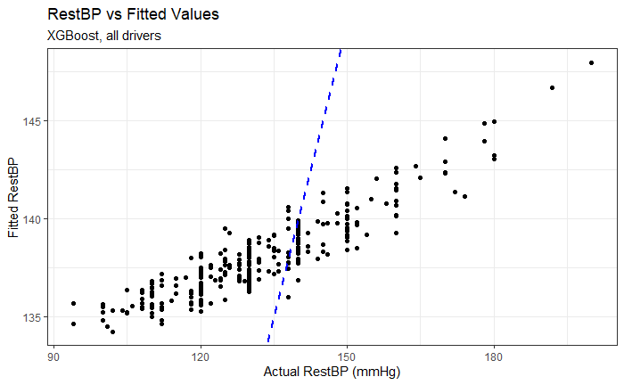

```r
plot.xg.all = ggplot(Heartall) +
  geom_point(aes(RestBP, pred.xg.all.unscaled))+
  geom_abline(aes(slope=1, intercept=0), color="blue", linetype="dashed", linewidth=1) +
  theme_bw() +
  labs(title="RestBP vs Fitted Values",
       subtitle="XGBoost, all drivers",
       x="Actual RestBP (mmHg)", y="Fitted RestBP")
plot.xg.all
```

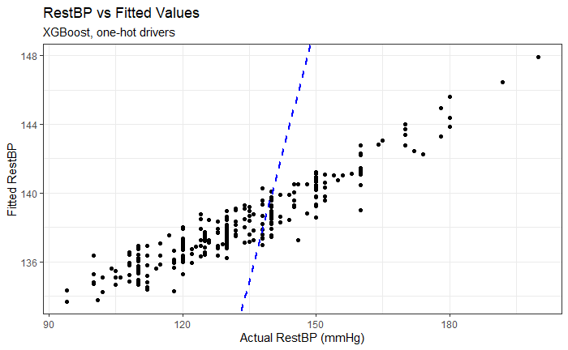

```r
plot.xg.oh = ggplot(dfx) +
  geom_point(aes(RestBP, pred.xg.oh.unscaled))+
  geom_abline(aes(slope=1, intercept=0), color="blue", linetype="dashed", linewidth=1) +
  theme_bw() +
  labs(title="RestBP vs Fitted Values",
       subtitle="XGBoost, one-hot drivers",
       x="Actual RestBP (mmHg)", y="Fitted RestBP")
plot.xg.oh
```

Quite biased.

## Importance

```r
importance_matrix = xgb.importance(names(Heartall.scaled_covariates_matrix),
                                   model=fit.xg.all)
importance_matrix
```

| Feature | Gain | Cover | Frequency |
| --- | --- | --- | --- |
| Chol | 0.25605936 | 0.2311010267 | 0.23174603 |
| Age | 0.22305460 | 0.1555725294 | 0.16825397 |
| MaxHR | 0.15827549 | 0.2773347112 | 0.22539683 |
| Oldpeak | 0.14684669 | 0.1048457754 | 0.12698413 |
| Ca | 0.03749674 | 0.0595331701 | 0.05396825 |
| Sex | 0.03338657 | 0.0367308427 | 0.03809524 |
| Thal | 0.02799655 | 0.0228921888 | 0.03809524 |
| ChestPain | 0.02592949 | 0.0214544066 | 0.02857143 |
| Fbs | 0.02108896 | 0.0286657830 | 0.01904762 |
| Slope | 0.02085440 | 0.0189607530 | 0.02539683 |

[output cut: 3 more lines]

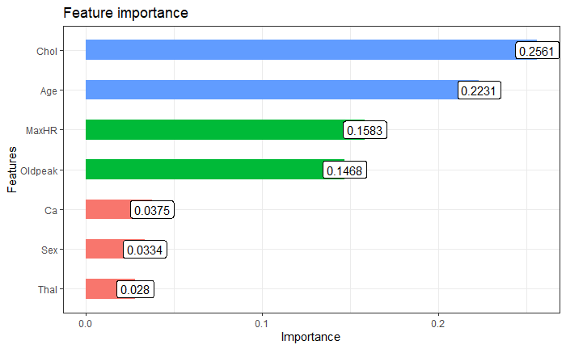

```r
library(Ckmeans.1d.dp) # required for ggplot version
xgb.ggplot.importance(importance_matrix, top_n = 7) +
  theme_bw() + theme(legend.position='none')+
  geom_label(aes(label=round(importance_matrix$Gain[1:7],4)))
```

## Feature plot

We can visualize a composite of all the trees used in the model. The numbers at the leaves are the odds of arriving at that leaf.

```r
library(DiagrammeR) # needs to be installed for this plot.
xgb.plot.multi.trees(feature_names = names(Heartall.scaled_covariates_matrix),
                     model = fit.xg.all, features_keep = 3)
```

[output not shown]

[interactive chart not shown]

```r
odds_to_probs <- function(odds){
    return(exp(odds)/ (1 + exp(odds)))
}

# probability of top leaf
odds_to_probs(-0.28412)
```

```
[1] 0.429444
```

There is a 43% likelihood of arriving in leaf 1 averaged over all trees included in the analysis for the model.

## Accuracy

```r
accuracy.rmse.xg.all = ModelMetrics::rmse(pred.xg.all.unscaled, Heartall$RestBP)
accuracy.rmse.xg.all
```

```
[1] 17.03321
```

The accuracy is 17.0332123.

```r
accuracy.rmse.xg.oh = ModelMetrics::rmse(pred.xg.oh.unscaled, dfx$RestBP)
accuracy.rmse.xg.oh
```

```
[1] 16.85
```

One-hot encoding helped a bit.

## Comparison

```r
AccuracyComparisonAll %>%
  mutate(XGB = accuracy.rmse.xg.all %>% round(digits=4)) %>%
  mutate(XGOH = accuracy.rmse.xg.oh %>% round(digits=4)) %>%
  mutate(Measure = "RMSE", .before=1) %>%
  DT::datatable(caption="Accuracy Comparison, all and one-hot drivers")
```

|  | Measure | OLS | NNET | RF | KNN | XGB | XGOH |
| --- | --- | --- | --- | --- | --- | --- | --- |
| 1 | RMSE | 16.1143 | 11.9764 | 8.3316 | 18.556 | 17.0332 | 16.85 |

# Conclusion

This XGBoost model, one-hot encoded or not, gives results worse than regression measured by RMSE as an accuracy. It appears to be quite biased, as was a neural net and a random forest.

One-hot encoding helped, but not a lot.

# References

1. [Amazon AWS: How XGBoost Works](https://docs.aws.amazon.com/sagemaker/latest/dg/xgboost-HowItWorks.html)
2. [Machine Learning with XGBoost (in R)](https://www.kaggle.com/code/rtatman/machine-learning-with-xgboost-in-r/notebook)
3. [Simplilearn: What is XGBoost?](https://www.simplilearn.com/what-is-xgboost-algorithm-in-machine-learning-article)